# Quality Control: Cell and Gene Filtering (patient 63)

Ramon Massoni-Badosa

2021/04/09

# 1 Introduction

The purpose of this notebook is to filter out poor quality cells and genes for the patient with id “63”.

# 2 Pre-processing

## 2.1 Load packages

```r
library(scater)
library(Seurat)
library(ggpubr)
library(tidyverse)
```

## 2.2 Parameters

```r
# Paths
path_to_obj <- here::here("results/R_objects/patient_63/1.seurat_object_unfiltered.rds")
path_to_save <- here::here("results/R_objects/patient_63/2.seurat_object_filtered.rds")


# Functions
source(here::here("bin/utils.R"))


# Thresholds
min_lib_size <- 150000
max_lib_size <- 700000
min_n_genes <- 550
max_n_genes <- 3750
max_pct_mt <- 18
min_cells <- 3
```

## 2.3 Load data

```r
# Read merged Seurat object
seurat <- readRDS(path_to_obj)
seurat
```

```
## An object of class Seurat
## 19427 features across 1150 samples within 1 assay
## Active assay: RNA (19427 features, 0 variable features)
```

# 3 Visualize experimental design

In this Smart-seq2 experiment, we had a total of 12 plates. We can visualize the experimental design with the [scater](https://academic.oup.com/bioinformatics/article/33/8/1179/2907823) package. (TODO)

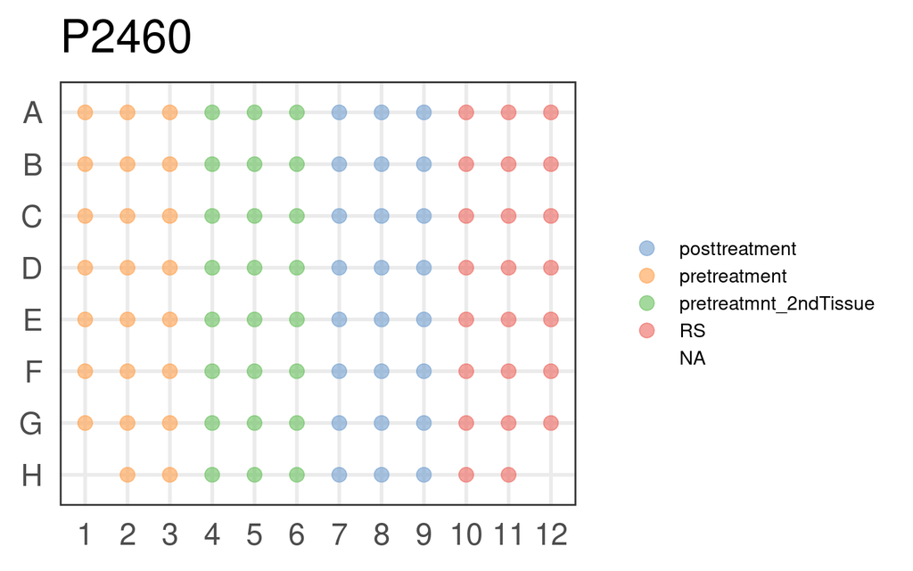

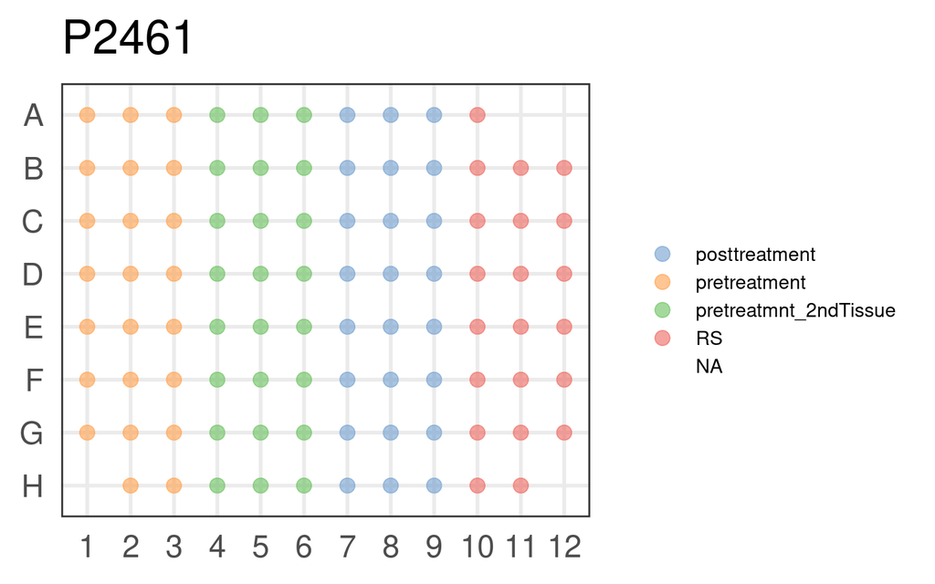

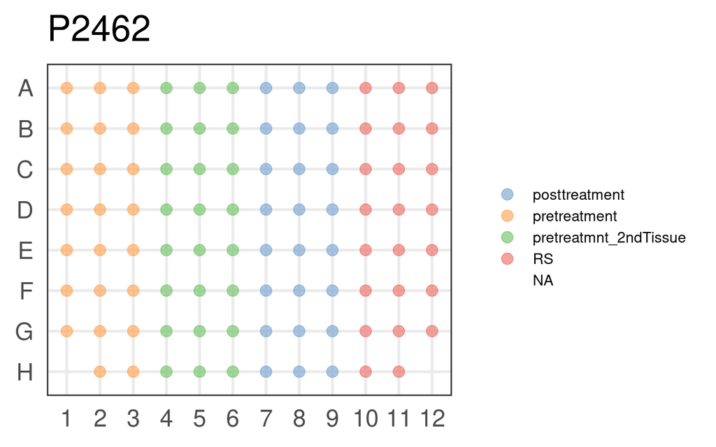

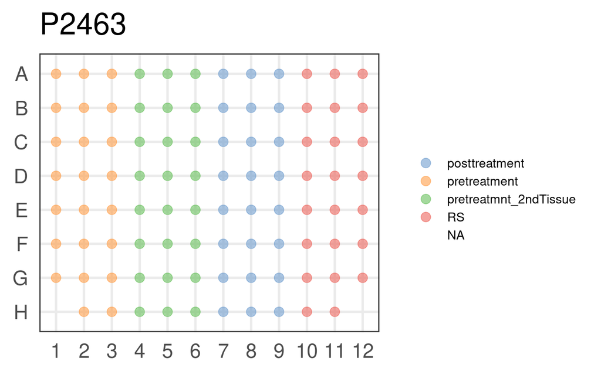

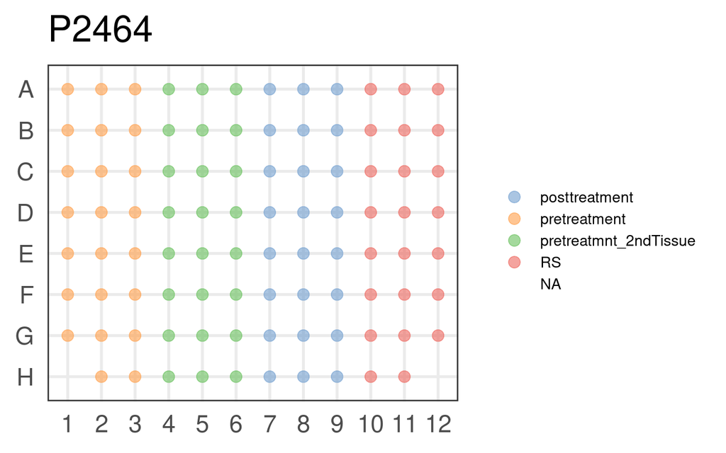

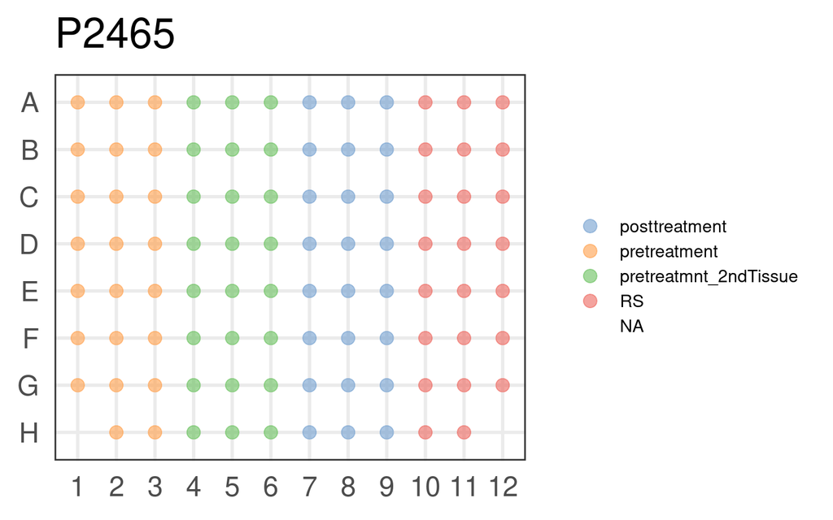

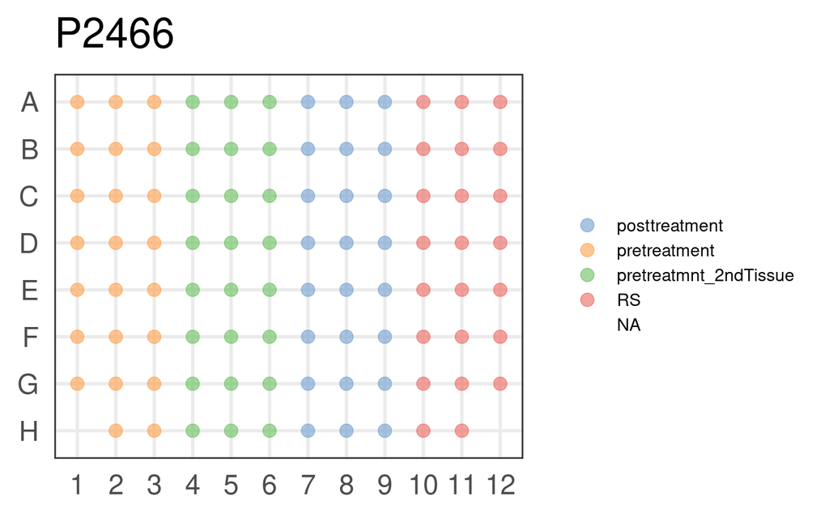

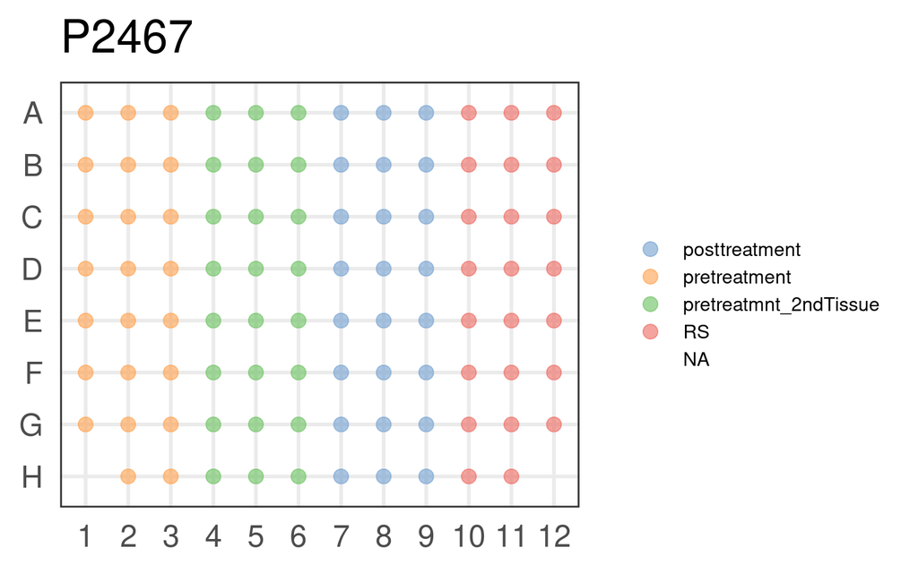

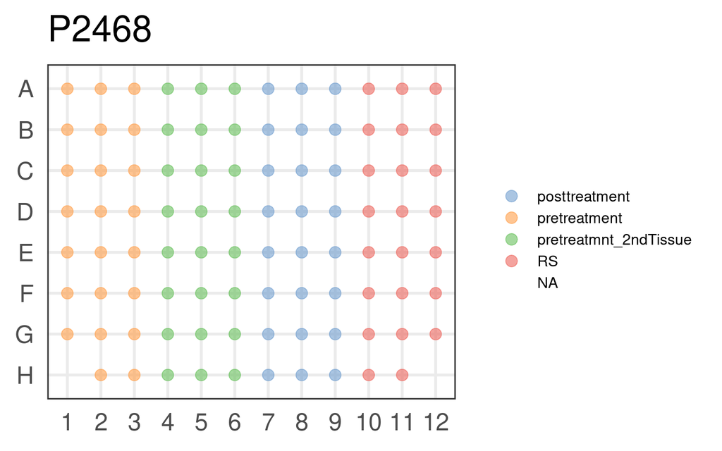

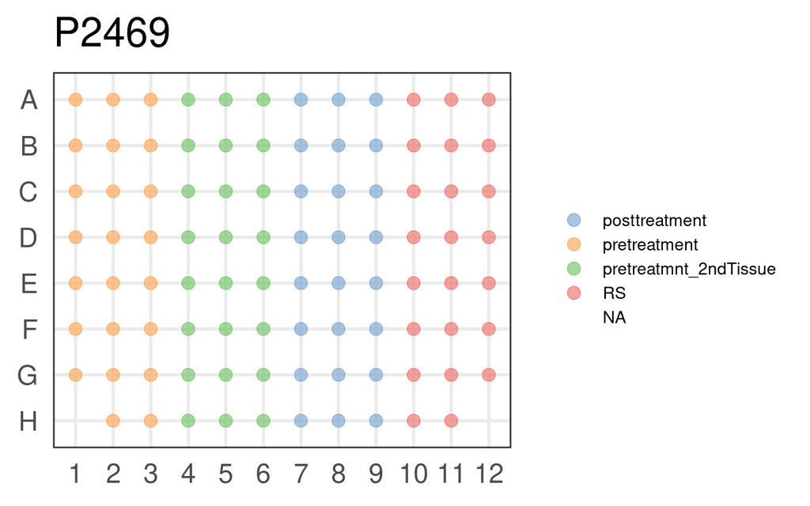

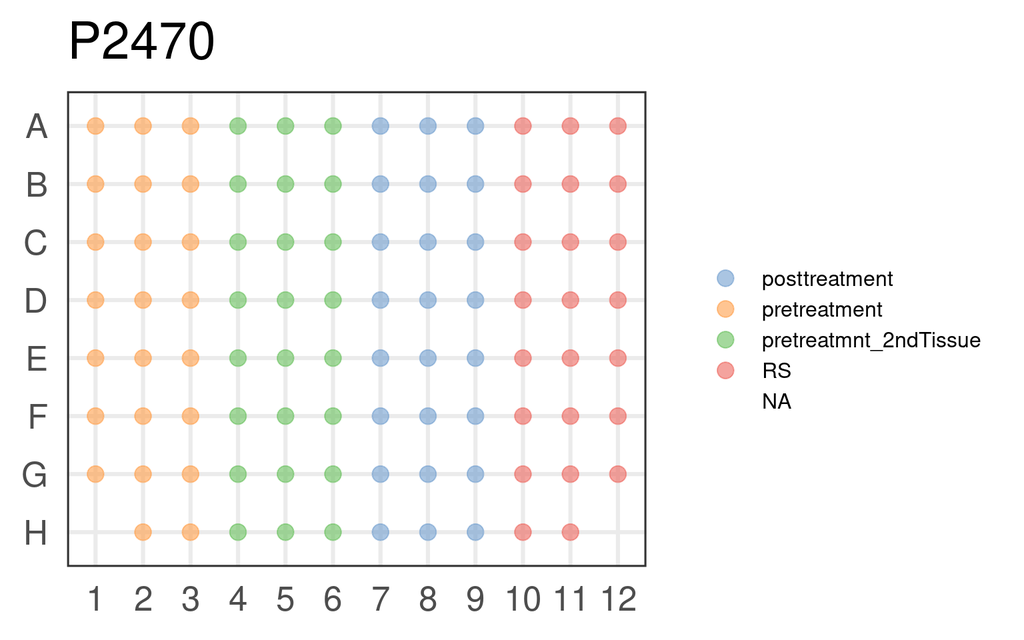

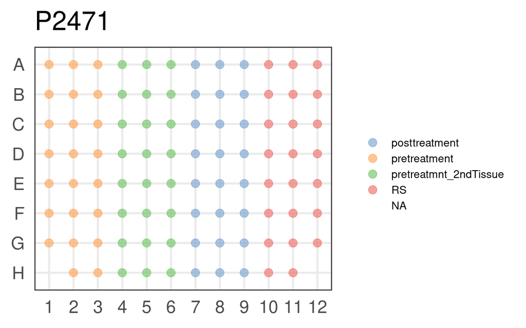

```r
plates <- sort(unique(seurat$plate))
seurat$well <- str_extract(seurat$well, "...$")
sce <- as.SingleCellExperiment(seurat)
plate_distrs <- map(plates, function(x){
  curr_sce <- sce[, sce$plate == x]
  plate_distr <- plotPlatePosition(
    curr_sce,
    plate_position = curr_sce$well,
    colour_by = "sample_description_FN",
    point_size = 4
  )
  plate_distr +
    ggtitle(x) +
    theme(plot.tag = element_text(hjust = 0.5),
          legend.title = element_blank())
})
names(plate_distrs) <- plates
plate_distrs
```

# 4 Distribution of QC variables

First, we want to see how the main QC variables distribute across samples. This will help us interpret the results downstream, as we will know which are the samples with lower quality.

## 4.1 Library complexity

```r
# Calculate mean library size
seurat$time_point[is.na(seurat$time_point)] <- "empty"
seurat$sample_id[is.na(seurat$sample_id)] <- "empty"
lib_complexity_df <- seurat@meta.data %>%
  dplyr::group_by(time_point, sample_id) %>%
  dplyr::summarise(
    mean_n_features = round(mean(nFeature_RNA), 2),
    sd_n_features = round(sd(nFeature_RNA), 2)) %>%
  dplyr::arrange(time_point)
print(lib_complexity_df)
```

```
## # A tibble: 5 x 4
## # Groups:   time_point [4]
##   time_point sample_id mean_n_features sd_n_features
##   <chr>      <chr>               <dbl>         <dbl>
## 1 empty      empty                53.5          61.8
## 2 T1         05/599              923.          287.
## 3 T1         05/76              1149.          412.
## 4 T2         10/7434             978.          384.
## 5 T3         14/2116            2324.          938.
```

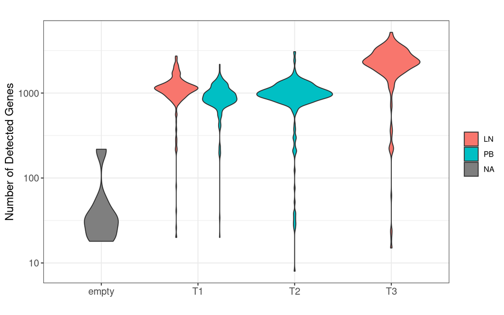

```r
# Plot library size distribution
lib_size_per_time_point <- seurat@meta.data %>%
  ggplot(aes(time_point, nFeature_RNA, fill = tissue)) +
    geom_violin() +
    scale_y_log10() +
    labs(title = "", x = "", y = "Number of Detected Genes") +
    theme_bw() +
    theme(
      plot.title = element_text(hjust = 0.5, size = 13),
      axis.text = element_text(size = 11),
      axis.title = element_text(size = 13),
      legend.title = element_blank()
    )
lib_size_per_time_point
```

Notice that the NA corresponds to the empty wells taht are used as negative control.

# 5 Filter out cells

We aim to detect and exclude empty droplets or lysed cells. Lysed cells have 3 hallmarks: (1) low library size (total UMI), (2) low library complexity (number of detected genes) and (3) high fraction of mitochondrial expression (cytosolic mRNA leaks out of the cell). Let us start by visualizing their univariate distributions.

## 5.1 Library Size

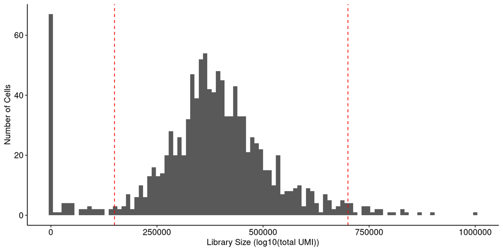

```r
lib_size_hist <- seurat@meta.data %>%
  plot_histogram_qc(x = "nCount_RNA", x_lab = "Library Size (log10(total UMI))") +
  geom_vline(xintercept = min_lib_size, linetype = "dashed", color = "red") +
  geom_vline(xintercept = max_lib_size, linetype = "dashed", color = "red")
lib_size_hist
```

## 5.2 Number of detected genes

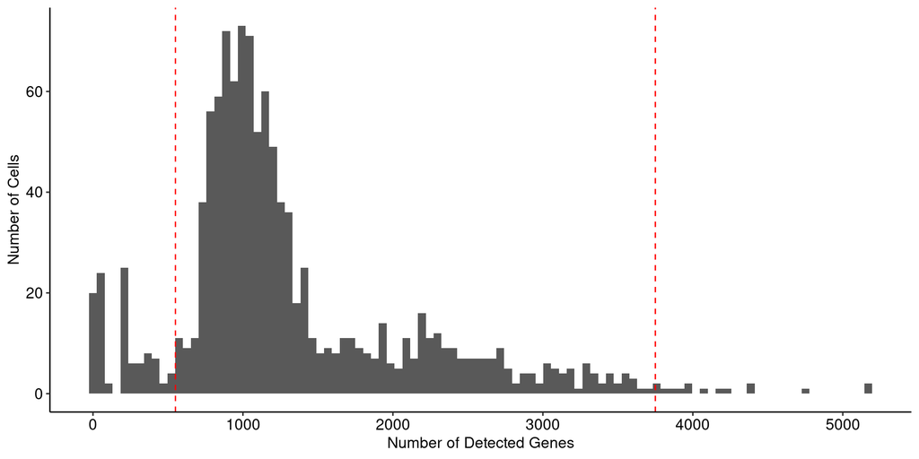

```r
n_genes_hist <- seurat@meta.data %>%
  plot_histogram_qc(x = "nFeature_RNA", x_lab = "Number of Detected Genes") +
  geom_vline(xintercept = min_n_genes, linetype = "dashed", color = "red") +
  geom_vline(xintercept = max_n_genes, linetype = "dashed", color = "red")
n_genes_hist
```

## 5.3 Fraction of mitochondrial expression

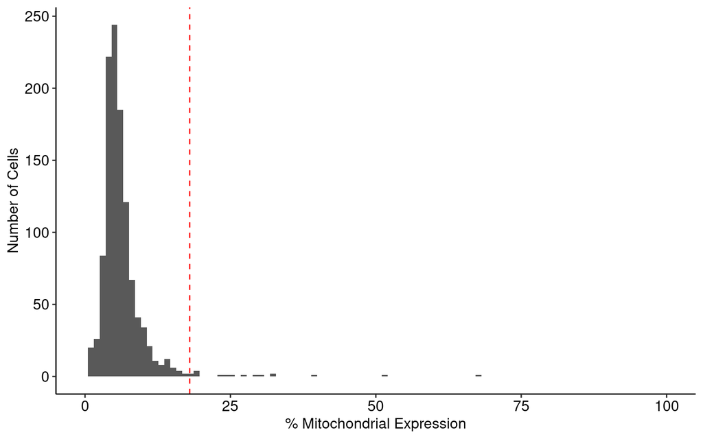

```r
# Calculate percentage of mitochondrial and ribosomal expression
seurat$pct_mt <- PercentageFeatureSet(seurat, pattern = "^MT-")


# Plot
pct_mt_hist <- seurat@meta.data %>%
  plot_histogram_qc(x = "pct_mt", x_lab = "% Mitochondrial Expression") +
  geom_vline(xintercept = max_pct_mt, linetype = "dashed", color = "red") +
  scale_x_continuous(limits = c(0, 100))
pct_mt_hist
```

## 5.4 Fraction of ribosomal expression

Let us also calculate and visualize the proportion of ribosomal expression:

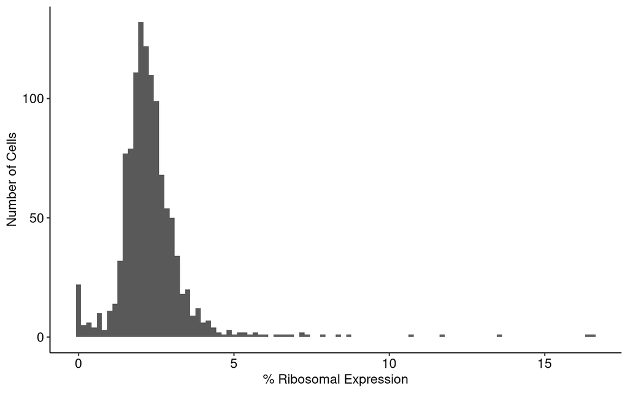

```r
seurat$pct_ribosomal <- PercentageFeatureSet(
  seurat,
  pattern = "^RPS"
)
pct_ribosomal_hist <- seurat@meta.data %>%
  plot_histogram_qc(x = "pct_ribosomal", x_lab = "% Ribosomal Expression")
pct_ribosomal_hist
```

## 5.5 Subset empty droplets and lysed cells

```r
metadata_before_qc <- seurat@meta.data
is_low_quality <-
  seurat$nCount_RNA < min_lib_size |
  seurat$nCount_RNA > max_lib_size |
  seurat$nFeature_RNA < min_n_genes |
  seurat$nFeature_RNA > max_n_genes |
  seurat$pct_mt > max_pct_mt
table(is_low_quality)
```

```
## is_low_quality
## FALSE  TRUE
##   983   167
```

```r
seurat$keep_cells <- !is_low_quality
Idents(seurat) <- "keep_cells"
seurat
```

```
## An object of class Seurat
## 19427 features across 1150 samples within 1 assay
## Active assay: RNA (19427 features, 0 variable features)
```

```r
seurat <- subset(seurat, idents = TRUE)
seurat
```

```
## An object of class Seurat
## 19427 features across 983 samples within 1 assay
## Active assay: RNA (19427 features, 0 variable features)
```

```r
metadata_after_qc <- seurat@meta.data
```

## 5.6 QC summary table

```r
qc_before <- metadata_before_qc %>%
  group_by(sample_id, time_point) %>%
  summarise(num_cells_before_qc = n())
qc_after <- metadata_after_qc %>%
  group_by(sample_id, time_point) %>%
  summarise(
    num_cells_after_qc = n(),
    average_library_size = mean(nCount_RNA),
    average_num_detected_genes = mean(nFeature_RNA),
    average_mitochondrial_fraction = mean(pct_mt)
  )
qc_table <- left_join(qc_before, qc_after, by = "sample_id")
DT::datatable(qc_table)
```

|  | sample_id | time_point.x | num_cells_before_qc | time_point.y | num_cells_after_qc | average_library_size | average_num_detected_genes | average_mitochondrial_fraction |
| --- | --- | --- | --- | --- | --- | --- | --- | --- |
| 1 | 05/599 | T1 | 276 | T1 | 250 | 405838.628 | 965.804 | 5.44430826625805 |
| 2 | 05/76 | T1 | 288 | T1 | 268 | 402104.98880597 | 1199.57462686567 | 4.80181321316726 |
| 3 | 10/7434 | T2 | 288 | T2 | 253 | 391155.841897233 | 1045.91304347826 | 5.65240000741311 |
| 4 | 14/2116 | T3 | 274 | T3 | 212 | 412182.476415094 | 2421.54245283019 | 8.44020933138612 |
| 5 | empty | empty | 24 |  |  |  |  |  |

# 6 Filter out genes

According to [Luecken MD et al.](https://www.embopress.org/doi/10.15252/msb.20188746): “A guideline to setting this threshold is to use the minimum cell cluster size that is of interest and leaving some leeway for dropout effects. For example, filtering out genes expressed in fewer than 20 cells may make it difficult to detect cell clusters with fewer than 20 cells. For datasets with high dropout rates, this threshold may also complicate the detection of larger clusters. The choice of threshold should scale with the number of cells in the dataset and the intended downstream analysis.”

## 6.1 Set threshold

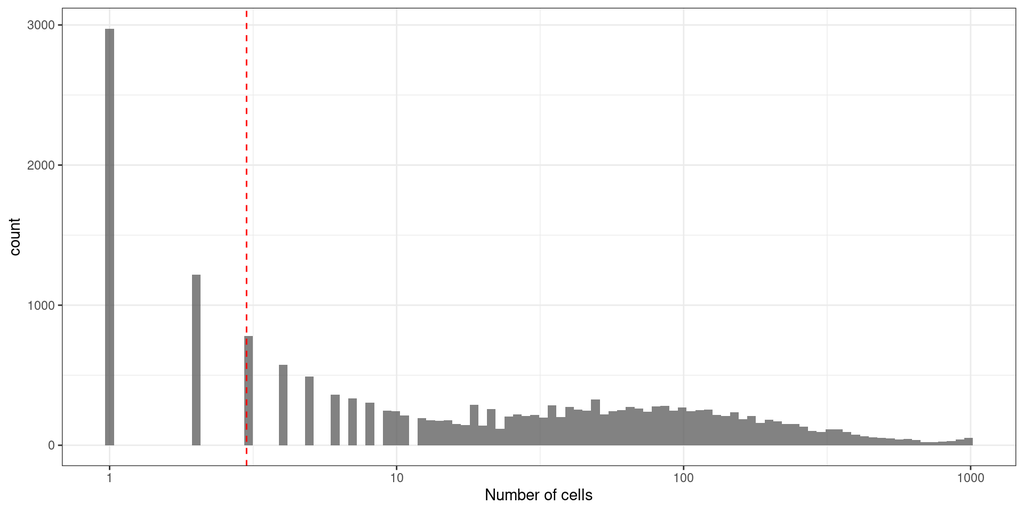

```r
n_cells <- Matrix::rowSums(seurat[["RNA"]]@counts > 0)
gene_qc <- n_cells %>%
  as.data.frame() %>%
  ggplot(aes(n_cells)) +
    geom_histogram(bins = 100, alpha = 0.75) +
    scale_x_log10("Number of cells") +
    theme_bw()
gene_qc +
  geom_vline(xintercept = min_cells, linetype = "dashed", color = "red")
```

## 6.2 Plot genes with highest expression

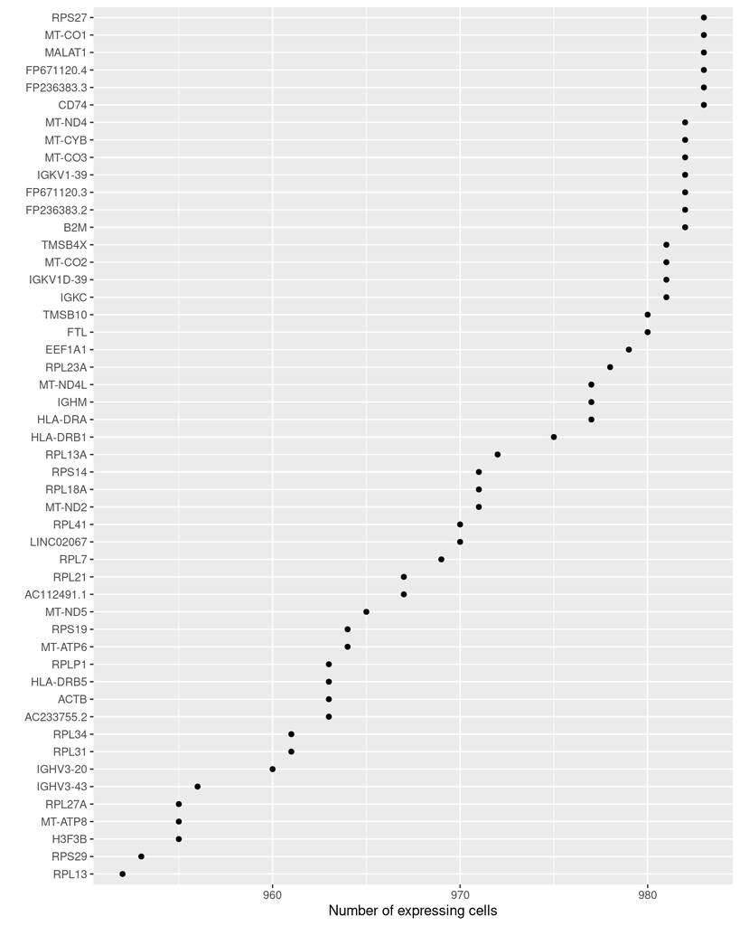

```r
top_50_genes <- sort(n_cells, decreasing = TRUE)[1:50]
top_50_genes_df <- data.frame(
  gene = names(top_50_genes),
  n_cells = top_50_genes
)
top_50_genes_df %>%
  ggplot(aes(fct_reorder(gene, n_cells), n_cells)) +
    geom_point() +
    labs(x = "", y = "Number of expressing cells") +
    coord_flip()
```

## 6.3 Filter

```r
kept_genes <- rownames(seurat)[n_cells > min_cells]
table(n_cells > min_cells)
```

```
##
## FALSE  TRUE
##  5747 13680
```

```r
seurat
```

```
## An object of class Seurat
## 19427 features across 983 samples within 1 assay
## Active assay: RNA (19427 features, 0 variable features)
```

```r
seurat <- subset(seurat, features = kept_genes)
seurat
```

```
## An object of class Seurat
## 13680 features across 983 samples within 1 assay
## Active assay: RNA (13680 features, 0 variable features)
```

# 7 Save filtered Seurat object

```r
saveRDS(seurat, path_to_save)
```